# HW4 BioStatistic

Bondareva Alina Kirillovna

2024-04-02

# Домашнее задание №4.

## Выполнила Бондарева Алина Кирилловна

**Тема:** использование основных статистических тестов и поправок на множественные сравнения.

**Цель:** разберем использование основных параметрических и непараметрических статистических тестов, научимся вводить поправки на множественные сравнения и поймем, чем они отличаются.

### **Задание 1**

Рассмотрите следующую статистическую гипотезу:

*Проводят некоторое исследование пациентов с артериальной гипертензией. Предположим, что внедрение нового препарата в среднем лучше снижает их давление по сравнению со стандартной терапией.*

*Задайте `seed` для воспроизводимости результатов (функция `set.seed())`. Задайте размер выборки `sample_size <- 30`. Задайте значение среднего артериального давления до приема нового препарата и после.*

Затем:

- Сформулируйте нулевую и альтернативную гипотезы.
- Определите уровень значимости.
- Выберите статистический тест для проверки гипотезы и аргументируйте свой выбор.
- Определите наблюдаемое значение статистики, а также критическое значение статистики.
- Оцените и прокомментируйте статистическую значимость.

```r
# Импортируем необходимые библиотеки
library(ggplot2)
library(tidyverse)
library(dplyr)
library(tibble)
```

```r
set.seed(123) # Устанавливаем seed для воспроизводимости
sample_size <- 30 # Размер выборки

# Генерируем данные (bp - blood pressure)
mean_bp_before <- 140
mean_bp_after <- 120

# Создаем набор данных для давления пациентов перед началом лечения, учитывая заданное отклонение
before_bp_sd <- 12
before_treatment_bp <- rnorm(n = sample_size, mean = mean_bp_before, sd = before_bp_sd)

# Создаем набор данных для давления пациентов после введения препарата с другим стандартным отклонением
after_bp_sd <- 10
after_treatment_bp <- rnorm(n = sample_size, mean = mean_bp_after, sd = after_bp_sd)

# Составляем датафрейм с измерениями до и после
blood_pressure_data <- data.frame(before_treatment = before_treatment_bp,
                                  after_treatment = after_treatment_bp)

# Предварительный просмотр данных
head(blood_pressure_data)
```

```
##   before_treatment after_treatment
## 1         133.2743        124.2646
## 2         137.2379        117.0493
## 3         158.7045        128.9513
## 4         140.8461        128.7813
## 5         141.5515        128.2158
## 6         160.5808        126.8864
```

Теперь нам необходимо сформировать гипотезы:

`H0` - **Артериальное давление до и после приема препарата статистически значимо не отличаются;**

`H1` - **Артериальное давление до и после приема препарата статистически значимо отличается.**

В медицинских исследованиях обычно используется уровень значимости
$$\alpha = 0.05$$
, что означает, что вероятность отклонить нулевую гипотезу, когда она верна, составляет 5%.

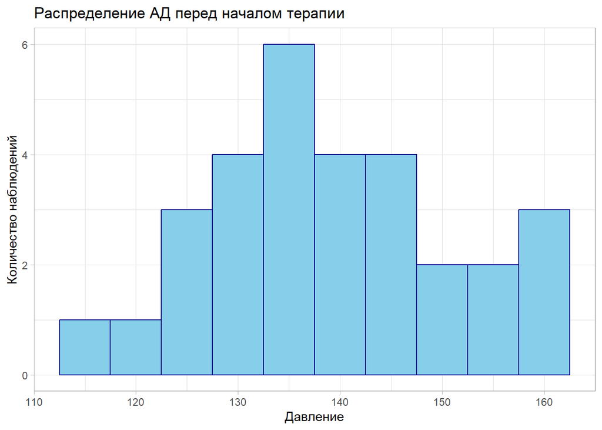

```r
# Проанализируем распределение давления пациентов перед лечением с помощью визульаных методов - гистограммы

ggplot(blood_pressure_data, aes(x = before_treatment)) +
  geom_histogram(binwidth = 5, fill = "skyblue", color = "darkblue") +
  labs(title = "Распределение АД перед началом терапии", x = "Давление", y = "Количество наблюдений") +
  theme_light()
```

Распределение кажется нормальным, но с отклонениями в правом хвосте.

Посмотрим для второй выборки:

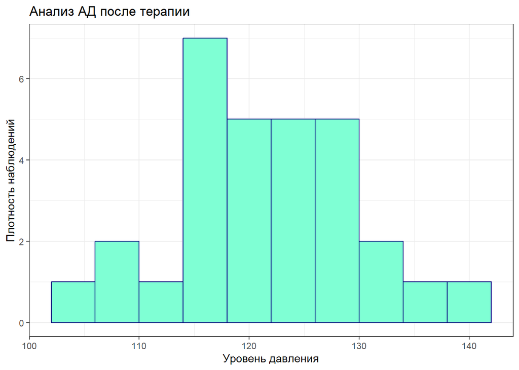

```r
# Проанализируем распределение давления пациентов после леченя с помощью визульаных методов - гистограммы
ggplot(blood_pressure_data, aes(x = after_treatment)) +
  geom_histogram(binwidth = 4, fill = "aquamarine", color = "navy") +
  labs(title = "Анализ АД после терапии", x = "Уровень давления", y = "Плотность наблюдений") +
  theme_bw()
```

Давайте теперь проверим обе выборки с помощью теста Шапиро-Уилка для уверенности:

```r
# Тест Шапиро-Уилка на нормальность
shapiro.test(blood_pressure_data$before_treatment)
```

```
##
##  Shapiro-Wilk normality test
##
## data:  blood_pressure_data$before_treatment
## W = 0.97894, p-value = 0.7966
```

```r
shapiro.test(blood_pressure_data$after_treatment)
```

```
##
##  Shapiro-Wilk normality test
##
## data:  blood_pressure_data$after_treatment
## W = 0.98662, p-value = 0.9614
```

Таким образом, значение `p-value` выше установленного порога альфа (
$$\alpha = 0.05$$
) в обеих проверках, у нас нет оснований отклонять нулевую гипотезу. Значит, распределение значений по обеим выборкам соответствует нормальному, несмотря на визуальное отличие. Мы будем придерживаться этого вывода.

Теперь, после того, как мы доказали нормальность распределения, мы можем провести попарный t-тест для поиска статистически значимых различий в выборках.

```r
t_test_result <- t.test(blood_pressure_data$before_treatment, blood_pressure_data$after_treatment, paired = TRUE)
print(t_test_result)
```

```
##
##  Paired t-test
##
## data:  blood_pressure_data$before_treatment and blood_pressure_data$after_treatment
## t = 6.2499, df = 29, p-value = 8.042e-07
## alternative hypothesis: true mean difference is not equal to 0
## 95 percent confidence interval:
##  11.87513 23.42761
## sample estimates:
## mean difference
##        17.65137
```

Результаты парного t-теста показывают статистически значимую разницу в артериальном давлении до и после лечения (p-value = 8.042e-07), что указывает на эффективность препарата. Среднее изменение артериального давления составило 17.65 единиц, с 95% доверительным интервалом от 11.88 до 23.43

Вычислим значение, превышающее которое различия считаются значимыми, для двустороннего теста с уровнем доверия 95%: (df - degrees of freedom, (что соответствует размеру выборки минус единица, sample_size - 1, для парного t-теста)

```r
alpha = 0.05
critical_value <- qt(1 - alpha / 2, df = (sample_size - 1))

critical_value
```

```
## [1] 2.04523
```

Исходя из полученных данных, значение t-статистики (t = 6.2499) существенно выше, чем критическое значение (critical_value = 2.04523), заданное для 29 степеней свободы при уровне значимости 5%.

Так как значение `p_value` меньше уровня значимости `alpha`, мы отклоняем нулевую гипотезу (`H0`) в пользу альтернативной (`H1`), указывая на наличие статистически подтвержденного различия в уровнях артериального давления до и после лечения, что свидетельствует об эффективности препарата для понижения систолического давления.

Доверительный интервал для разности средних не охватывает нуль, дополнительно подтверждая статистическую значимость наблюдаемых различий.